# Separation by regression quantiles

Anton Antonov

`2019-04-14`

# Introduction

Basic, introductory example to illustrate how Quantile Regression works using the package [QRMon](https://github.com/antononcube/QRMon-R).

For detailed explanations see the vignette [“Rapid making of Quantile Regression workflows”](https://htmlpreview.github.io/?https://github.com/antononcube/QRMon-R/blob/master/notebooks/rapid-making-of-qr-workflows.html).

Here is a [diagram](https://github.com/antononcube/MathematicaForPrediction/raw/master/MarkdownDocuments/Diagrams/A-monad-for-Quantile-Regression-workflows/QRMon-pipeline.jpg) showing the concepts in a QRMon pipeline (in Mathematica notation.)

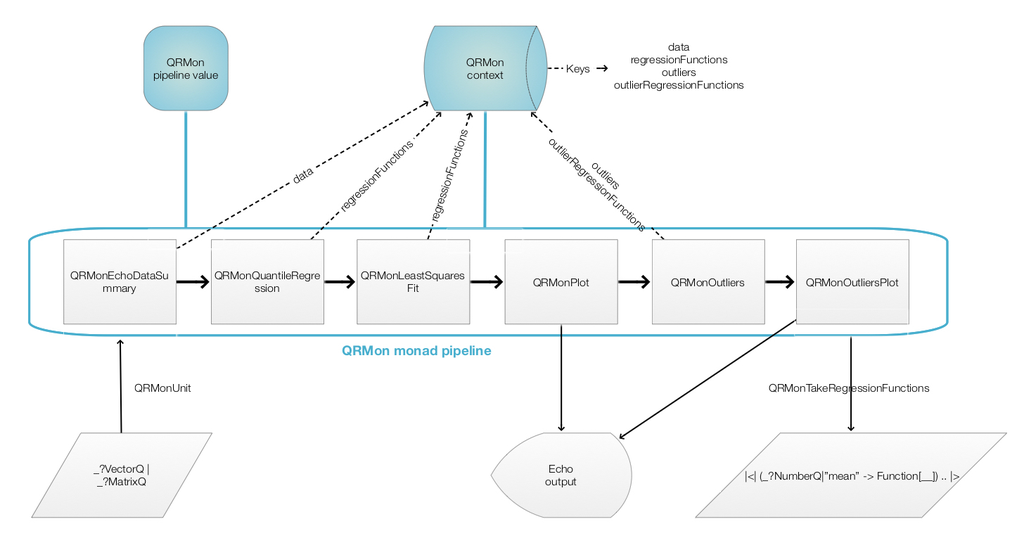

QRMon pipeline in Mathematica

# Installation and libraries load

The package/library QRMon can be installed with the command:

```r
devtools::install_github("antononcube/QRMon-R")
```

Then we load that package with:

```r
library(QRMon)
```

Sometimes I have to explicitly load the dependency libraries:

```r
library(splines)
library(quantreg)
library(purrr)
library(magrittr)
library(ggplot2)
```

Those libraries can be installed with the command:

```r
install.packages( "quantreg", "purrr", "magrittr", "ggplot2")
```

# Computation pipelines

Below the curves produced by Quantile Regression are called “regression quantiles”.

## The monad object

A QRMon monad object is a S3 object and it is constructed with`QRMonUnit`.

Here are the S3 object element names:

```r
names(QRMonUnit())
```

```
[1] "Value"             "Data"              "RegressionObjects" "Outliers"
```

Here is the class attribute:

```r
class(QRMonUnit())
```

```
[1] "QRMon"
```

**Remarks:**

- The class attribute is not used/respected in QRMon’s functions because they use the prefix “QRMon”.
- Some of QRMon’s functions can put additional elements into the monad object.

## Fractions of points

Here we compute the fractions of the points separated by the regression quantiles with the following pipeline:

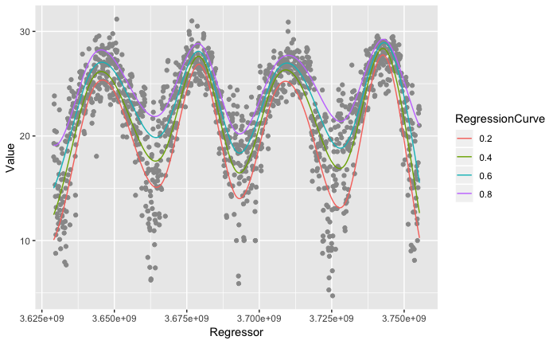

```r
qFracs <-
  QRMonUnit( setNames(dfTemperatureData, c("Regressor", "Value")) ) %>%  # Get data
  QRMonQuantileRegression( df = 12, probabilities = seq(0.2,0.8,0.2) ) %>%   # Quantile Regression with B-splines
  QRMonPlot %>%                                                          # Plot data and regression quantiles
  QRMonSeparateToFractions %>%                                           # Separate the points and find fractions
  QRMonTakeValue                                                         # Take the value of the monad object
```

```r
qFracs
```

```
      0.2       0.4       0.6       0.8
0.2046543 0.4024641 0.6043806 0.8035592
```

The above result should :

- illustrate what Quantile Regression does, and
- convince us that the concrete QRMon implementation works.

Consider the application of the points separation process for finding (and defining) outliers.

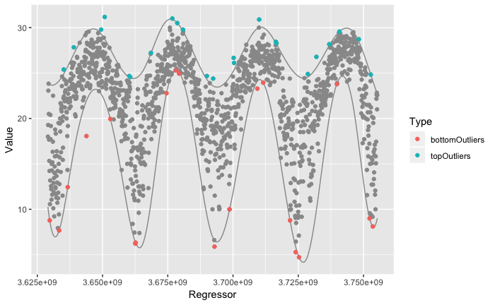

```r
qrObj<-
 QRMonUnit( setNames(dfTemperatureData, c("Regressor", "Value")) ) %>%
  QRMonQuantileRegression( df = 16, probabilities = c(0.01,0.98) ) %>%
  QRMonOutliers %>%
  QRMonOutliersPlot
```

## Separated points with different colors

Let use make a more interesting example by plotting the points separated by the regression quantiles with different colors.

### Separation

First we compute a non-cumulative point separation:

```
The argument data is expected to be a data frame with columns: { Regressor, Value }.Proceeding by renaming the first columm "Time" as "Regressor" and renaming the second columm "Value" as "Value".
```

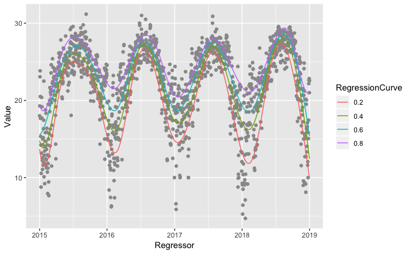

```r
qFracPoints <-
  QRMonUnit( setNames( dfTemperatureData, c("Time", "Value") ) ) %>%
  QRMonQuantileRegression( df = 16, probabilities = seq(0.2,0.8,0.2) ) %>%
  QRMonPlot(datePlotQ = T, dateOrigin = "1900-01-01") %>%               # Make a date-axis plot
  QRMonSeparate( cumulativeQ = FALSE ) %>%                              # Non-cumulative point sets
  QRMonTakeValue()
```

The following result shows that the found point sets have roughly the same number of elements that adhere to the selected quantile proabilities.

```r
rbind(
  purrr::map_df(qFracPoints, nrow),
  purrr::map_df(qFracPoints, nrow) / nrow(dfTemperatureData)
)
```

| 0.2 | 0.4 | 0.6 | 0.8 |
| --- | --- | --- | --- |
| 299.0000000 | 277.0000000 | 308.0000000 | 280.0000000 |
| 0.2046543 | 0.1895962 | 0.2108145 | 0.1916496 |

### Plot

Here we plot the separated points with different colors:

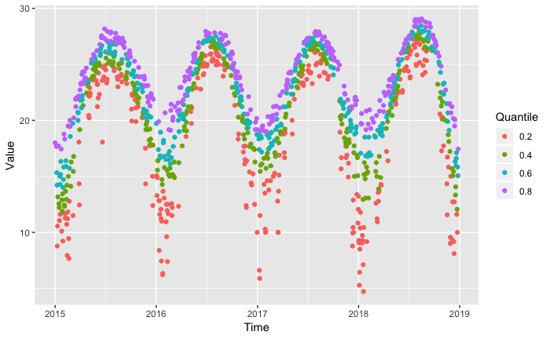

```r
qDF <- dplyr::bind_rows( qFracPoints , .id = "Quantile")
qDF$Time <- as.POSIXct( qDF$Regressor, origin = "1900-01-01" )
ggplot(qDF) +
  geom_point(aes(x = Time, y = Value, color = Quantile) )
```

# Further application of the separation

One of the unique applications of Quantile Regression is to do “realistic” time series simulations.

Let us first do Quantile Regression fit of the time series data:

```
The argument data is expected to be a data frame with columns: { Regressor, Value }.Proceeding by renaming the first columm "Time" as "Regressor" and renaming the second columm "Value" as "Value".
```

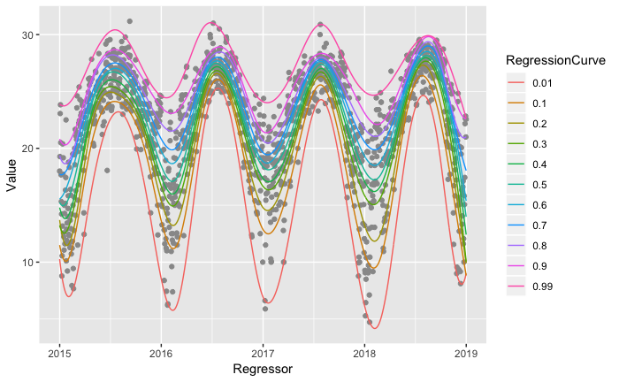

```r
qrmon <-
  QRMonUnit( setNames(dfTemperatureData, c("Time", "Value") )) %>%
  QRMonQuantileRegression( df = 16, probabilities = c( 0.01, seq(0.1,0.9,0.1), 0.99) ) %>%
  QRMonPlot(datePlotQ = TRUE, dateOrigin = "1900-01-01" )
```

Here with the obtained monad object we do several time series simulations over 1000 regular grid points:

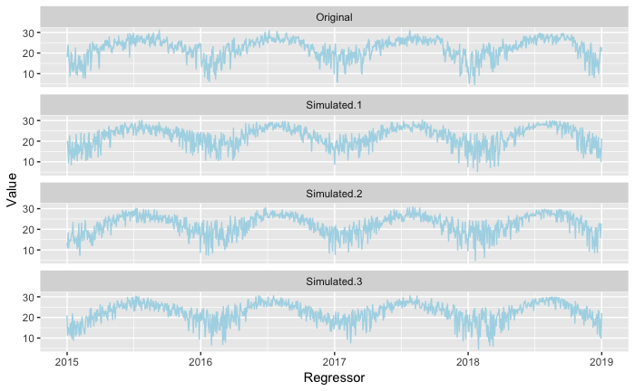

```r
set.seed(2223)
qDF <- rbind( cbind( Type = "Original", qrmon %>% QRMonTakeData() ),
              cbind( Type = "Simulated.1", as.data.frame( qrmon %>% QRMonSimulate(1000) %>% QRMonTakeValue() )),
              cbind( Type = "Simulated.2", as.data.frame( qrmon %>% QRMonSimulate(1000) %>% QRMonTakeValue() )),
              cbind( Type = "Simulated.3", as.data.frame( qrmon %>% QRMonSimulate(1000) %>% QRMonTakeValue() ))
              )
qDF$Regressor <- as.POSIXct( qDF$Regressor, origin = "1900-01-01" )
ggplot( qDF ) +
  geom_line( aes( x = Regressor, y = Value ), color = "lightblue" ) +
  facet_wrap( ~Type, ncol=1)
```

Simulations like these can be used in some Operations Research applications.